# main

### 统计学：检验心理学现象

在下方单元格中回答问题并执行相关代码，你可以 参考项目指导 并在正式提交前查看 [项目要求](https://review.udacity.com/#!/rubrics/305/view)。提交时请将 Jupyter notebook 导出成 HTML 或者 PDF 进行提交（File -> Download As）。

背景信息

在一个Stroop （斯特鲁普）任务中，参与者得到了一列文字，每个文字都用一种油墨颜色展示。参与者的任务是将文字的打印颜色大声说出来。这项任务有两个条件：一致文字条件，和不一致文字条件。在一致文字条件中，显示的文字是与它们的打印颜色匹配的颜色词，如“红色”、“蓝色”。在不一致文字条件中，显示的文字是与它们的打印颜色不匹配的颜色词，如“紫色”、“橙色”。在每个情况中，我们将计量说出同等大小的列表中的墨色名称的时间。每位参与者必须全部完成并记录每种条件下使用的时间。

调查问题

作为一般说明，请确保记录你在创建项目时使用或参考的任何资源。作为项目提交的一部分，你将需要报告信息来源。

(1) 我们的自变量是什么？因变量是什么？

- 自变量：参与者接收测试的列表中，显示的文字“墨色”是否与它们的打印颜色匹配
- 因变量：说出同等大小列表中的墨色名称的时间

(2) 此任务的适当假设集是什么？你需要以文字和数学符号方式对假设集中的零假设和对立假设加以说明，并对数学符号进行定义。你想执行什么类型的统计检验？为你的选择提供正当理由（比如，为何该实验满足你所选统计检验的前置条件）。

*假设集*：

- 零假设 $H_{0}$： $\mu _{d}=0$,一致条件与不一致条件之差的总体均值等于0
- 对立假设 $H_{1}$ ： $\mu _{d}\neq0$，一致条件与不一致条件之差的总体均值不等于0

*选择执行配对t检验，原因*：

- 样本数小于30，总体的均值与标准差未知
- 同一个测试者分别在条件一致和条件不一致的情况下进行配对测试，因此是配对样本
- 因为本问题是相同对象在不同情况下的测试，因此配对t检验是合适的分析方法，可用以确定两个配对样本之差的均值不等于0，计算可能包含差异总体均值的值的范围

*配对t检验的前提假设*：

- 原始数据是连续数据
- 可以通过原始数据计算得到一个总体均数、一个样本均数及该样本标准差
- 两样本是配对的（数量一样，顺序不变），且原始数据符合正态分布或近似于正态分布

现在轮到你自行尝试 Stroop 任务了。前往此链接，其中包含一个基于 Java 的小程序，专门用于执行 Stroop 任务。记录你收到的任务时间（你无需将时间提交到网站）。现在下载此数据集，其中包含一些任务参与者的结果。数据集的每行包含一名参与者的表现，第一个数字代表他们的一致任务结果，第二个数字代表不一致任务结果。

(3) 报告关于此数据集的一些描述性统计。包含至少一个集中趋势测量和至少一个变异测量。

```python
import pandas as pd
import numpy as np

%matplotlib inline

df = pd.read_csv('stroopdata.csv')
```

为了想了解同一参与者在文字一致和不一致条件下，参与者说出同等大小的列表中的墨色名称的时间差异，故增加一列数据Difference = Incongruent Time- Congruent Time，处理后数据集如下

```python
df['Difference'] = df.Incongruent - df.Congruent
```

```python
df
```

|  | Congruent | Incongruent | Difference |
| --- | --- | --- | --- |
| 0 | 12.079 | 19.278 | 7.199 |
| 1 | 16.791 | 18.741 | 1.950 |
| 2 | 9.564 | 21.214 | 11.650 |
| 3 | 8.630 | 15.687 | 7.057 |
| 4 | 14.669 | 22.803 | 8.134 |
| 5 | 12.238 | 20.878 | 8.640 |
| 6 | 14.692 | 24.572 | 9.880 |
| 7 | 8.987 | 17.394 | 8.407 |
| 8 | 9.401 | 20.762 | 11.361 |
| 9 | 14.480 | 26.282 | 11.802 |
| 10 | 22.328 | 24.524 | 2.196 |
| 11 | 15.298 | 18.644 | 3.346 |
| 12 | 15.073 | 17.510 | 2.437 |
| 13 | 16.929 | 20.330 | 3.401 |
| 14 | 18.200 | 35.255 | 17.055 |
| 15 | 12.130 | 22.158 | 10.028 |
| 16 | 18.495 | 25.139 | 6.644 |
| 17 | 10.639 | 20.429 | 9.790 |
| 18 | 11.344 | 17.425 | 6.081 |
| 19 | 12.369 | 34.288 | 21.919 |
| 20 | 12.944 | 23.894 | 10.950 |
| 21 | 14.233 | 17.960 | 3.727 |
| 22 | 19.710 | 22.058 | 2.348 |
| 23 | 16.004 | 21.157 | 5.153 |

```python
df.info()
```

```
<class 'pandas.core.frame.DataFrame'>
RangeIndex: 24 entries, 0 to 23
Data columns (total 3 columns):
Congruent      24 non-null float64
Incongruent    24 non-null float64
Difference     24 non-null float64
dtypes: float64(3)
memory usage: 656.0 bytes
```

```python
df.describe()
```

|  | Congruent | Incongruent | Difference |
| --- | --- | --- | --- |
| count | 24.000000 | 24.000000 | 24.000000 |
| mean | 14.051125 | 22.015917 | 7.964792 |
| std | 3.559358 | 4.797057 | 4.864827 |
| min | 8.630000 | 15.687000 | 1.950000 |
| 25% | 11.895250 | 18.716750 | 3.645500 |
| 50% | 14.356500 | 21.017500 | 7.666500 |
| 75% | 16.200750 | 24.051500 | 10.258500 |
| max | 22.328000 | 35.255000 | 21.919000 |

小结:

- 该数据集共3列变量，分别为Congruent、Incongruent、Difference，每一组各有24个数据
- 在文字内容与打印颜色不一致的情况下，其均值、标准差、最小值、最大值及其各四分位点均高于条件一致的情况下
- 新增列Difference中均为正值，表明了所有数据样本中，条件不一致情况下所花费的时间均大于一致时

(4) 提供显示样本数据分布的一个或两个可视化。用一两句话说明你从图中观察到的结果。

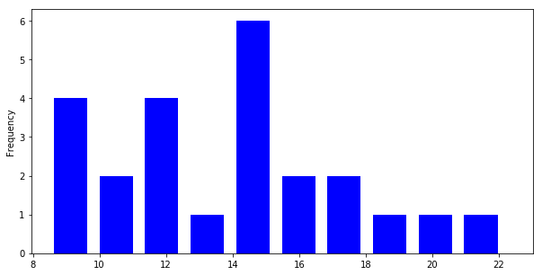

```python
df.Congruent.plot.hist(width=1,figsize=(10,5), color='blue')
```

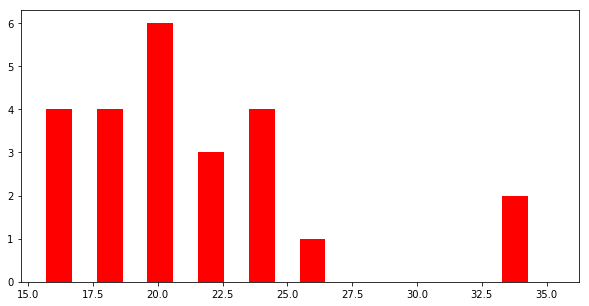

```python
df.Incongruent.hist(width=1, figsize=(10,5), grid=False, color='red')
```

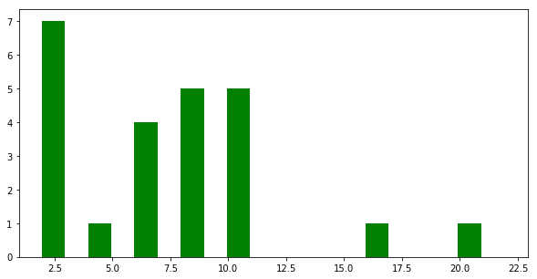

```python
df.Difference.hist(width=1, figsize=(10,5), grid=False, color='green')
```

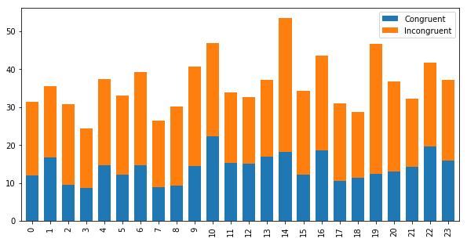

```python
df[['Congruent', 'Incongruent']].plot.bar(stacked=True, width=0.7, figsize=(10,5))
```

(5) 现在，执行统计测试并报告你的结果。你的置信水平和关键统计值是多少？你是否成功拒绝零假设？对试验任务得出一个结论。结果是否与你的期望一致？

#### 做出假设

- 零假设 $H_{0}$： $\mu _{d}=0$,一致条件与不一致条件之差的总体均值等于0
- 对立假设 $H_{1}$ ： $\mu _{d}\neq0$，一致条件与不一致条件之差的总体均值不等于0
- 显著性水平 α = 0.05

#### 求数据的均值、和、平方和，为简化书写，设变量：

- d = Difference

```python
d = df.Difference

d_mean = np.mean(d)
d_sum = np.sum(d)
d_sum_of_square = np.sum(np.square(d))
```

#### 计算$S_{d}$

$$S_{d}=\sqrt{\frac{ \sum_{ }^{ }d^{2}-(\sum_{ }^{ }d^{ })^{2}/n }{n-1}}$$

```python
Sd = np.sqrt((d_sum_of_square - np.square(d_sum)/len(d)) / (len(d)-1))

print(Sd)
```

```
4.86482691036
```

#### 计算t值

$$t=\frac{|\bar{d}|}{S_{d}/\sqrt{n}}$$

```python
t = abs(d_mean) / (Sd/np.sqrt(len(d)))
v = len(d) - 1
print(t,v)
```

```
8.02070694411 23
```

#### 查相应分布表，确定P值

- $t_{0.025,23}$ = 2.0687, 因此t > $t_{0.025,23}$
- P<0.05

#### 结论：

按照α=0.05水准，拒绝零假设$H_{0}$，接受对立假设$H_{1}$，结论表明在显示的文字与它们的打印颜色是否匹配的条件不一致时，对测试者的反应时间有明显影响。

### Reference：

- 王志江.概率论与数理统计[M].北京: 高等教育出版社, 2011. *假设检验*
- [中心极限定理 - 维基百科](https://zh.wikipedia.org/wiki/%E4%B8%AD%E5%BF%83%E6%9E%81%E9%99%90%E5%AE%9A%E7%90%86)
- [LaTex公式编辑器](http://latex.codecogs.com/eqneditor/editor.php)
- [标准t分布表](http://staff.ustc.edu.cn/~jbs/applex3.pdf)
- [t检验的类型细分](http://support.minitab.com/zh-cn/minitab/17/topic-library/basic-statistics-and-graphs/hypothesis-tests/tests-of-means/types-of-t-tests/)
- [z-test or t-test](http://www.statisticshowto.com/probability-and-statistics/hypothesis-testing/t-score-vs-z-score/)